# Project: The Movie Database Data Analysis

- Introduction
- Data Wrangling
- Exploratory Data Analysis
- Conclusions

## Introduction

The aim of this project was to analyse The Movie Database (TMDb) movie dataset which was originally sourced from Kaggle and has been cleaned and provided by Udacity for the 'Investigate a Dataset' Project as part of the Data Analyst Nanodegree. The TMDb dataset collects information about over 10,000 movies from the years 1960 to 2015 and includes columns such as popularity, budget, revenue, cast, director genre, production companies, release date, vote count, vote average, and budget and revenue adjusted for inflation. As noted in the TMDb dataset overview and notes provided by Udacity, there are some odd characters in the 'cast' column which do not need to be cleaned therefore this column's data has been left in its original state. Additionally, the dataset notes highlight that the final two columns for budget and revenue ending in 'adj' contain the budget and revenue of associated movies in terms of 2010 dollars accounting for inflation over time.

This report intends to effectively answer the following questions:

1. What kinds of properties are associated with movies that have high revenues?
2. What kinds of properties are associated with movies that have highest popularity scores?
3. What kinds of properties are associated with movies that have highest voting scores?
4. Have movie budgets increased over time?
5. Have movie revenues increased over time?
6. Has the popularity score and average rating for movies increased over time?
7. What are the most popular genres from 1960-2015?

This report will demonstrate the overall data analysis process and the accompanying Python code used to answer the aforementioned questions and provide justification for the decisions made throughout the analysis. It is important to note that inferential statistics and machine learning are beyond the scope of this course therefore findings and conclusions drawn in this report are tentative.

```python
# Import packages
import numpy as np
import pandas as pd
import matplotlib.pyplot as plt
import seaborn as sns
%matplotlib inline
sns.set()
```

## Data Wrangling

This section of the report demonstrates loading and inspecting the data, check for cleanliness, and then trimming and cleaning the dataset for analysis. It is important to understand the structure of the data and the different columns contained in the dataset before beginning Exploratory Data Analysis.

### Assessing the General Properties of the Data

The first step in the data wrangling process is to load the data and inspect the first few rows as shown below.

```python
# Load data and print out a few lines

df = pd.read_csv('tmdb-movies.csv')
#df.columns
df.head()
```

|  | id | imdb_id | popularity | budget | revenue | original_title | cast | homepage | director | tagline | ... | overview | runtime | genres | production_companies | release_date | vote_count | vote_average | release_year | budget_adj | revenue_adj |
| --- | --- | --- | --- | --- | --- | --- | --- | --- | --- | --- | --- | --- | --- | --- | --- | --- | --- | --- | --- | --- | --- |
| 0 | 135397 | tt0369610 | 32.985763 | 150000000 | 1513528810 | Jurassic World | Chris Pratt\|Bryce Dallas Howard\|Irrfan Khan\|Vi... | http://www.jurassicworld.com/ | Colin Trevorrow | The park is open. | ... | Twenty-two years after the events of Jurassic ... | 124 | Action\|Adventure\|Science Fiction\|Thriller | Universal Studios\|Amblin Entertainment\|Legenda... | 6/9/15 | 5562 | 6.5 | 2015 | 1.379999e+08 | 1.392446e+09 |
| 1 | 76341 | tt1392190 | 28.419936 | 150000000 | 378436354 | Mad Max: Fury Road | Tom Hardy\|Charlize Theron\|Hugh Keays-Byrne\|Nic... | http://www.madmaxmovie.com/ | George Miller | What a Lovely Day. | ... | An apocalyptic story set in the furthest reach... | 120 | Action\|Adventure\|Science Fiction\|Thriller | Village Roadshow Pictures\|Kennedy Miller Produ... | 5/13/15 | 6185 | 7.1 | 2015 | 1.379999e+08 | 3.481613e+08 |
| 2 | 262500 | tt2908446 | 13.112507 | 110000000 | 295238201 | Insurgent | Shailene Woodley\|Theo James\|Kate Winslet\|Ansel... | http://www.thedivergentseries.movie/#insurgent | Robert Schwentke | One Choice Can Destroy You | ... | Beatrice Prior must confront her inner demons ... | 119 | Adventure\|Science Fiction\|Thriller | Summit Entertainment\|Mandeville Films\|Red Wago... | 3/18/15 | 2480 | 6.3 | 2015 | 1.012000e+08 | 2.716190e+08 |
| 3 | 140607 | tt2488496 | 11.173104 | 200000000 | 2068178225 | Star Wars: The Force Awakens | Harrison Ford\|Mark Hamill\|Carrie Fisher\|Adam D... | http://www.starwars.com/films/star-wars-episod... | J.J. Abrams | Every generation has a story. | ... | Thirty years after defeating the Galactic Empi... | 136 | Action\|Adventure\|Science Fiction\|Fantasy | Lucasfilm\|Truenorth Productions\|Bad Robot | 12/15/15 | 5292 | 7.5 | 2015 | 1.839999e+08 | 1.902723e+09 |
| 4 | 168259 | tt2820852 | 9.335014 | 190000000 | 1506249360 | Furious 7 | Vin Diesel\|Paul Walker\|Jason Statham\|Michelle ... | http://www.furious7.com/ | James Wan | Vengeance Hits Home | ... | Deckard Shaw seeks revenge against Dominic Tor... | 137 | Action\|Crime\|Thriller | Universal Pictures\|Original Film\|Media Rights ... | 4/1/15 | 2947 | 7.3 | 2015 | 1.747999e+08 | 1.385749e+09 |

5 rows × 21 columns

From the above result, it can be inferred that the dataset is tidy however it is noted that columns such as cast, genres, and production companies contain different values for the same movie. This is because one movie can fall under multiple different genres for example and these values are separated by a pipe character. This is noted for later during data wrangling.

#### Data Attributes

Below is a table containing the name of the column and its description;

| Column Name | Description |
| --- | --- |
| id | Unique identification number given to each row in the dataset |
| imdb_id | Unique identification number given to each row in the imdb dataset |
| popularity | The popularity score for the movie calculated using a variety of metrics* |
| budget | The original budget spent on the movie in dollars |
| revenue | The original revenue made from the movie in dollars |
| original_title | The original title of the movie |
| cast | The main cast starring in the film |
| homepage | The movie's website homepage |
| director | The director of the film |
| tagline | The movie's tagline |
| keywords | Keywords which relate to the associated movie |
| overview | The movie's synopsis |
| runtime | The length of the movie in minutes |
| genres | The genres which the movie falls under |
| production_companies | The production companies involved in making the movie |
| release_date | When the movie was originally released |
| vote_count | The number of votes cast regarding the rating of the movie |
| vote_average | The average score the movie was voted |
| release_year | The original year in which the movie was released |
| budget_adj | The budget spent on the movie which has been adjusted in terms of 2010 dollars accounting for inflation over time |
| revenue_adj | The revenue made from the movie which has been adjusted in terms of 2010 dollars accounting for inflation over time |

*popularity is calculated using a variety of metrics as listed here: https://developers.themoviedb.org/3/getting-started/popularity

Now that the data has been loaded and the columns have been investigated, the next thing of interest is the shape of the data.

```python
# Looking at the shape of the data
df.shape
```

```
(10866, 21)
```

From the above output, we can see that there are 10866 movies in the dataset and there are 21 columns. The next thing to investigate was summary statistics in order to gain a better understanding of the data.

```python
df.describe()
```

|  | id | popularity | budget | revenue | runtime | vote_count | vote_average | release_year | budget_adj | revenue_adj |
| --- | --- | --- | --- | --- | --- | --- | --- | --- | --- | --- |
| count | 10866.000000 | 10866.000000 | 1.086600e+04 | 1.086600e+04 | 10866.000000 | 10866.000000 | 10866.000000 | 10866.000000 | 1.086600e+04 | 1.086600e+04 |
| mean | 66064.177434 | 0.646441 | 1.462570e+07 | 3.982332e+07 | 102.070863 | 217.389748 | 5.974922 | 2001.322658 | 1.755104e+07 | 5.136436e+07 |
| std | 92130.136561 | 1.000185 | 3.091321e+07 | 1.170035e+08 | 31.381405 | 575.619058 | 0.935142 | 12.812941 | 3.430616e+07 | 1.446325e+08 |
| min | 5.000000 | 0.000065 | 0.000000e+00 | 0.000000e+00 | 0.000000 | 10.000000 | 1.500000 | 1960.000000 | 0.000000e+00 | 0.000000e+00 |
| 25% | 10596.250000 | 0.207583 | 0.000000e+00 | 0.000000e+00 | 90.000000 | 17.000000 | 5.400000 | 1995.000000 | 0.000000e+00 | 0.000000e+00 |
| 50% | 20669.000000 | 0.383856 | 0.000000e+00 | 0.000000e+00 | 99.000000 | 38.000000 | 6.000000 | 2006.000000 | 0.000000e+00 | 0.000000e+00 |
| 75% | 75610.000000 | 0.713817 | 1.500000e+07 | 2.400000e+07 | 111.000000 | 145.750000 | 6.600000 | 2011.000000 | 2.085325e+07 | 3.369710e+07 |
| max | 417859.000000 | 32.985763 | 4.250000e+08 | 2.781506e+09 | 900.000000 | 9767.000000 | 9.200000 | 2015.000000 | 4.250000e+08 | 2.827124e+09 |

From the summary statistics it is clear that the movie database contains movies from the years 1960-2015 as shown in the release_year column's minimum and maximum values. It is also evident that there are runtimes, budgets and revenues which contain values of 0 which is something that needs to be investigated further as it looks like there are missing values in the dataset. We can see the range for popularity is 0.000065 - 32.99, the range for vote_average is from 1.5 to 9.2 and this is an assumed rating scale from 1 to 10. It is also important to note that the vote_count ranges from 10 to 9767 therefore this is something that may need to be taken into consideration.

```python
# Perform operations to inspect data types and look for instances of missing or possibly errant data.
df.info()
```

```
<class 'pandas.core.frame.DataFrame'>
RangeIndex: 10866 entries, 0 to 10865
Data columns (total 21 columns):
 #   Column                Non-Null Count  Dtype
---  ------                --------------  -----
 0   id                    10866 non-null  int64
 1   imdb_id               10856 non-null  object
 2   popularity            10866 non-null  float64
 3   budget                10866 non-null  int64
 4   revenue               10866 non-null  int64
 5   original_title        10866 non-null  object
 6   cast                  10790 non-null  object
 7   homepage              2936 non-null   object
 8   director              10822 non-null  object
 9   tagline               8042 non-null   object
 10  keywords              9373 non-null   object
 11  overview              10862 non-null  object
 12  runtime               10866 non-null  int64
 13  genres                10843 non-null  object
 14  production_companies  9836 non-null   object
 15  release_date          10866 non-null  object
 16  vote_count            10866 non-null  int64
 17  vote_average          10866 non-null  float64
 18  release_year          10866 non-null  int64
 19  budget_adj            10866 non-null  float64
 20  revenue_adj           10866 non-null  float64
dtypes: float64(4), int64(6), object(11)
memory usage: 1.7+ MB
```

From the above operation it is clear that imbd_id, cast, homepage, director, tagline, keywords, overview, genres, production_companies all having missing values since there should be 10866 entries for each column. In order to clean the dataset, the columns with a significant number of missing values and which are not relevant to answer the questions of the analysis will be dropped in the next section of the data wrangling process.

When considering the datatypes for each of the columns that are relevant to the investigation these seem reasonable and will be left as they are.

### Data Cleaning

This stage in the data wrangling process will involve dropping unnecessary rows and columns which are not relevant to answering the questions posed at the beginning of this process. It will go on to clean duplicates and null values.

#### Dropping Unnecessary Columns

In this section, the columns which are not relevant to answering our questions will be dropped. Budget and revenue are dropped so that the adjusted values can be employed in our investigation as these are more meaningful when comparing movies from the earliest years in our dataset (1960s) to more recent years.

```python
# Performing data cleaning by first dropping unnecessary columns
df.drop(['id','imdb_id', 'budget', 'revenue', 'original_title', 'cast', 'homepage', 'director', 'tagline', 'keywords', 'overview', 'production_companies', 'release_date'], axis=1, inplace=True)
```

```python
# Check that dropping the above columns worked as expected
df.head()
```

|  | popularity | runtime | genres | vote_count | vote_average | release_year | budget_adj | revenue_adj |
| --- | --- | --- | --- | --- | --- | --- | --- | --- |
| 0 | 32.985763 | 124 | Action\|Adventure\|Science Fiction\|Thriller | 5562 | 6.5 | 2015 | 1.379999e+08 | 1.392446e+09 |
| 1 | 28.419936 | 120 | Action\|Adventure\|Science Fiction\|Thriller | 6185 | 7.1 | 2015 | 1.379999e+08 | 3.481613e+08 |
| 2 | 13.112507 | 119 | Adventure\|Science Fiction\|Thriller | 2480 | 6.3 | 2015 | 1.012000e+08 | 2.716190e+08 |
| 3 | 11.173104 | 136 | Action\|Adventure\|Science Fiction\|Fantasy | 5292 | 7.5 | 2015 | 1.839999e+08 | 1.902723e+09 |
| 4 | 9.335014 | 137 | Action\|Crime\|Thriller | 2947 | 7.3 | 2015 | 1.747999e+08 | 1.385749e+09 |

#### Removing Duplicates

In this section, duplicate values will be investigated and dropped.

```python
# Checking to see if there are any duplicates in the data
sum(df.duplicated())
```

```
1
```

From the above, it is clear that there is 1 duplicate value in the data which we can drop.

```python
#drop the duplicated data
df.drop_duplicates(inplace = True)
```

```python
# Check to see if dropping duplicates worked
sum(df.duplicated())
```

```
0
```

#### Removing Null Values

The next stage in our data wrangling process is investigating null and zero values in the dataset.

```python
# Searching for the number of nulls in the dataset
df.isnull().sum()
```

```
popularity       0
runtime          0
genres          23
vote_count       0
vote_average     0
release_year     0
budget_adj       0
revenue_adj      0
dtype: int64
```

It is evident here that we have 23 null values for genre so these will now be removed.

```python
#drop rows with any null values in dataset
df.dropna(inplace=True)
```

```python
# check if any columns have null values
df.isnull().sum()
```

```
popularity      0
runtime         0
genres          0
vote_count      0
vote_average    0
release_year    0
budget_adj      0
revenue_adj     0
dtype: int64
```

As shown from above there are now no null values in the dataset. However, earlier in our initial exploration of the data it was noticed that the min values for budget_adj and revenue_adj were actually 0 which at first glance doesn't make a lot of sense as it is highly unlikely that movies were made with 0 budget and this would result in inaccurate conclusions which could be drawn. The zero values are now going to be investigated.

#### Handling Missing Values

As shown below, there are zero values for budget_adj, revenue_adj as well as runtime. It is assumed that these are infact missing values and should be nulls instead of zeros as movies will always have a budget associated and a runtime of over 0 minutes. This is a point in the analysis process where it is important to decide whether to drop these associated rows, replace the zeros with nulls, or replace the zeros with the mean. After investigating the number of rows that are affected by zero values it doesn't make sense to drop these rows. Additionally, the budget_adj and revenue_adj are of interest and are relevant to our questions posed initially therefore it is decided that to rectify the number of zero values we will replacing the zeros with nulls. This decision was made so that the data wasn't distorted and misleading.

```python
df.describe()
```

|  | popularity | runtime | vote_count | vote_average | release_year | budget_adj | revenue_adj |
| --- | --- | --- | --- | --- | --- | --- | --- |
| count | 10842.000000 | 10842.000000 | 10842.000000 | 10842.000000 | 10842.000000 | 1.084200e+04 | 1.084200e+04 |
| mean | 0.647461 | 102.138443 | 217.823649 | 5.974064 | 2001.314794 | 1.758712e+07 | 5.147797e+07 |
| std | 1.001032 | 31.294612 | 576.180993 | 0.934257 | 12.813617 | 3.433437e+07 | 1.447723e+08 |
| min | 0.000065 | 0.000000 | 10.000000 | 1.500000 | 1960.000000 | 0.000000e+00 | 0.000000e+00 |
| 25% | 0.208210 | 90.000000 | 17.000000 | 5.400000 | 1995.000000 | 0.000000e+00 | 0.000000e+00 |
| 50% | 0.384532 | 99.000000 | 38.000000 | 6.000000 | 2006.000000 | 0.000000e+00 | 0.000000e+00 |
| 75% | 0.715393 | 111.000000 | 146.000000 | 6.600000 | 2011.000000 | 2.092507e+07 | 3.387838e+07 |
| max | 32.985763 | 900.000000 | 9767.000000 | 9.200000 | 2015.000000 | 4.250000e+08 | 2.827124e+09 |

Here we can see that for both budget_adj and revenue_adj there are minimum values of 0 and also 0 is the result at the 25th and 50th percentile.

```python
# Counting number of zeros in budget_adj
zeros_bud=df.query('budget_adj == "0"')
zeros_bud.budget_adj.count()
```

```
5674
```

```python
# Counting number of zeros in budget_adj
zeros_rev=df.query('revenue_adj == "0"')
zeros_rev.budget_adj.count()
```

```
5993
```

```python
# Counting number of zeros in runtime
zeros_run=df.query('runtime == "0"')
zeros_run.runtime.count()
```

```
30
```

It is evident that there is a significant number of 0 values in both budget_adj and revenue_adj columns which must be highlighted and which underlines the fact that the conclusions drawn from this analysis are tentative. In spite of this in order to answer the questions posed at the beginning of this process these 0 values will be filled with nulls for the reasons stated above.

```python
## Replacing zeros with nulls for budget_adj
df['budget_adj'] = df['budget_adj'].replace(0, np.NaN)
```

```python
## Replacing zeros with nulls for revenue_adj
df['revenue_adj'] = df['revenue_adj'].replace(0, np.NaN)
```

```python
## Replacing zeros with nulls for runtime
df['runtime'] = df['runtime'].replace(0, np.NaN)
```

```python
# check if any columns have null values
df.isnull().sum()
```

```
popularity         0
runtime           30
genres             0
vote_count         0
vote_average       0
release_year       0
budget_adj      5674
revenue_adj     5993
dtype: int64
```

Since runtime only has 30 missing values it is decided that these will be dropped from the dataset.

```python
## Removing null rows from runtime column
df.dropna(subset=["runtime"], inplace = True)
```

```python
## Checking dropping nulls from runtime worked
df.isnull().sum()
```

```
popularity         0
runtime            0
genres             0
vote_count         0
vote_average       0
release_year       0
budget_adj      5647
revenue_adj     5963
dtype: int64
```

```python
df.info()
```

```
<class 'pandas.core.frame.DataFrame'>
Int64Index: 10812 entries, 0 to 10865
Data columns (total 8 columns):
 #   Column        Non-Null Count  Dtype
---  ------        --------------  -----
 0   popularity    10812 non-null  float64
 1   runtime       10812 non-null  float64
 2   genres        10812 non-null  object
 3   vote_count    10812 non-null  int64
 4   vote_average  10812 non-null  float64
 5   release_year  10812 non-null  int64
 6   budget_adj    5165 non-null   float64
 7   revenue_adj   4849 non-null   float64
dtypes: float64(5), int64(2), object(1)
memory usage: 760.2+ KB
```

```python
df.describe()
```

|  | popularity | runtime | vote_count | vote_average | release_year | budget_adj | revenue_adj |
| --- | --- | --- | --- | --- | --- | --- | --- |
| count | 10812.000000 | 10812.000000 | 10812.000000 | 10812.000000 | 10812.000000 | 5.165000e+03 | 4.849000e+03 |
| mean | 0.648730 | 102.421846 | 218.369404 | 5.975379 | 2001.288938 | 3.691521e+07 | 1.151009e+08 |
| std | 1.001976 | 30.871363 | 576.886018 | 0.934122 | 12.819746 | 4.196662e+07 | 1.988557e+08 |
| min | 0.000065 | 2.000000 | 10.000000 | 1.500000 | 1960.000000 | 9.210911e-01 | 2.370705e+00 |
| 25% | 0.209045 | 90.000000 | 17.000000 | 5.400000 | 1995.000000 | 8.108664e+06 | 1.046585e+07 |
| 50% | 0.385298 | 99.000000 | 38.000000 | 6.000000 | 2006.000000 | 2.274082e+07 | 4.395666e+07 |
| 75% | 0.716608 | 112.000000 | 146.000000 | 6.600000 | 2011.000000 | 5.008384e+07 | 1.316482e+08 |
| max | 32.985763 | 900.000000 | 9767.000000 | 9.200000 | 2015.000000 | 4.250000e+08 | 2.827124e+09 |

Now that the 0s have been replaced by nulls the summary statistics make more sense. Next I will consider the genre column which is currently separated by pipes ('|').

#### Genre Column

```python
## To analyse which genres are most popular from year to year it is important to split genres up
dummies = df['genres'].str.get_dummies('|') # split by pipes
genre = pd.concat([df, dummies], axis=1) # concatenate dummies with df
genre
```

|  | popularity | runtime | genres | vote_count | vote_average | release_year | budget_adj | revenue_adj | Action | Adventure | ... | History | Horror | Music | Mystery | Romance | Science Fiction | TV Movie | Thriller | War | Western |
| --- | --- | --- | --- | --- | --- | --- | --- | --- | --- | --- | --- | --- | --- | --- | --- | --- | --- | --- | --- | --- | --- |
| 0 | 32.985763 | 124.0 | Action\|Adventure\|Science Fiction\|Thriller | 5562 | 6.5 | 2015 | 1.379999e+08 | 1.392446e+09 | 1 | 1 | ... | 0 | 0 | 0 | 0 | 0 | 1 | 0 | 1 | 0 | 0 |
| 1 | 28.419936 | 120.0 | Action\|Adventure\|Science Fiction\|Thriller | 6185 | 7.1 | 2015 | 1.379999e+08 | 3.481613e+08 | 1 | 1 | ... | 0 | 0 | 0 | 0 | 0 | 1 | 0 | 1 | 0 | 0 |
| 2 | 13.112507 | 119.0 | Adventure\|Science Fiction\|Thriller | 2480 | 6.3 | 2015 | 1.012000e+08 | 2.716190e+08 | 0 | 1 | ... | 0 | 0 | 0 | 0 | 0 | 1 | 0 | 1 | 0 | 0 |
| 3 | 11.173104 | 136.0 | Action\|Adventure\|Science Fiction\|Fantasy | 5292 | 7.5 | 2015 | 1.839999e+08 | 1.902723e+09 | 1 | 1 | ... | 0 | 0 | 0 | 0 | 0 | 1 | 0 | 0 | 0 | 0 |
| 4 | 9.335014 | 137.0 | Action\|Crime\|Thriller | 2947 | 7.3 | 2015 | 1.747999e+08 | 1.385749e+09 | 1 | 0 | ... | 0 | 0 | 0 | 0 | 0 | 0 | 0 | 1 | 0 | 0 |
| ... | ... | ... | ... | ... | ... | ... | ... | ... | ... | ... | ... | ... | ... | ... | ... | ... | ... | ... | ... | ... | ... |
| 10861 | 0.080598 | 95.0 | Documentary | 11 | 7.4 | 1966 | NaN | NaN | 0 | 0 | ... | 0 | 0 | 0 | 0 | 0 | 0 | 0 | 0 | 0 | 0 |
| 10862 | 0.065543 | 176.0 | Action\|Adventure\|Drama | 20 | 5.7 | 1966 | NaN | NaN | 1 | 1 | ... | 0 | 0 | 0 | 0 | 0 | 0 | 0 | 0 | 0 | 0 |
| 10863 | 0.065141 | 94.0 | Mystery\|Comedy | 11 | 6.5 | 1966 | NaN | NaN | 0 | 0 | ... | 0 | 0 | 0 | 1 | 0 | 0 | 0 | 0 | 0 | 0 |
| 10864 | 0.064317 | 80.0 | Action\|Comedy | 22 | 5.4 | 1966 | NaN | NaN | 1 | 0 | ... | 0 | 0 | 0 | 0 | 0 | 0 | 0 | 0 | 0 | 0 |
| 10865 | 0.035919 | 74.0 | Horror | 15 | 1.5 | 1966 | 1.276423e+05 | NaN | 0 | 0 | ... | 0 | 1 | 0 | 0 | 0 | 0 | 0 | 0 | 0 | 0 |

10812 rows × 28 columns

```python
dummies.head() # check that dummies is working as expected
```

|  | Action | Adventure | Animation | Comedy | Crime | Documentary | Drama | Family | Fantasy | Foreign | History | Horror | Music | Mystery | Romance | Science Fiction | TV Movie | Thriller | War | Western |
| --- | --- | --- | --- | --- | --- | --- | --- | --- | --- | --- | --- | --- | --- | --- | --- | --- | --- | --- | --- | --- |
| 0 | 1 | 1 | 0 | 0 | 0 | 0 | 0 | 0 | 0 | 0 | 0 | 0 | 0 | 0 | 0 | 1 | 0 | 1 | 0 | 0 |
| 1 | 1 | 1 | 0 | 0 | 0 | 0 | 0 | 0 | 0 | 0 | 0 | 0 | 0 | 0 | 0 | 1 | 0 | 1 | 0 | 0 |
| 2 | 0 | 1 | 0 | 0 | 0 | 0 | 0 | 0 | 0 | 0 | 0 | 0 | 0 | 0 | 0 | 1 | 0 | 1 | 0 | 0 |
| 3 | 1 | 1 | 0 | 0 | 0 | 0 | 0 | 0 | 1 | 0 | 0 | 0 | 0 | 0 | 0 | 1 | 0 | 0 | 0 | 0 |
| 4 | 1 | 0 | 0 | 0 | 1 | 0 | 0 | 0 | 0 | 0 | 0 | 0 | 0 | 0 | 0 | 0 | 0 | 1 | 0 | 0 |

```python
total_genre = dummies.loc['Total'] = pd.Series(dummies.sum()) # run once to get sum for each genre
total_genre
```

```
Action             2382
Adventure          1470
Animation           699
Comedy             3782
Crime              1353
Documentary         517
Drama              4751
Family             1229
Fantasy             915
Foreign             187
History             334
Horror             1629
Music               401
Mystery             808
Romance            1705
Science Fiction    1228
TV Movie            164
Thriller           2905
War                 270
Western             165
dtype: int64
```

## Exploratory Data Analysis

Now that our data has been wrangled, the next stage of the data analysis process is to conduct exploratory data analysis by computing statistics and creating visualisations with the goal of addressing the research questions posed at the beginning of this process.

First we will look at the histograms and scatterplots for each of our columns with quantitative data to gain a better understanding of the distribution.

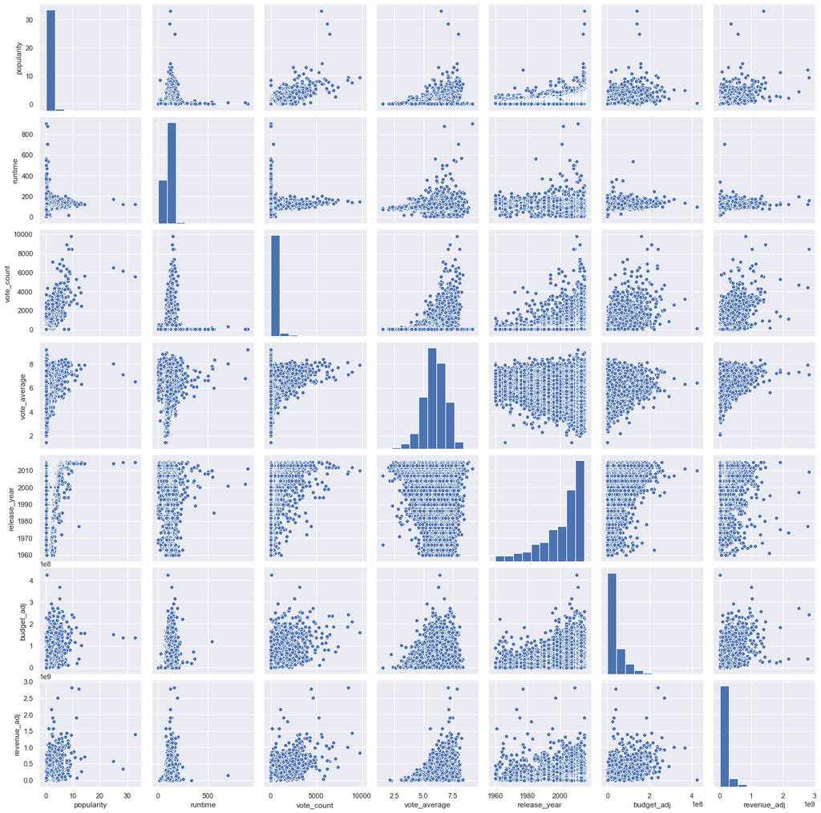

```python
## plotting seaborns pairplot to show relationships

sns.pairplot(df);
```

### What kinds of properties are associated with movies that have high revenues?

The first question in the investigation is concerned with what kinds of properties are associated with movies that have high revenues. In order to gain a better understanding of possible correlations a series of scatterplots are created.

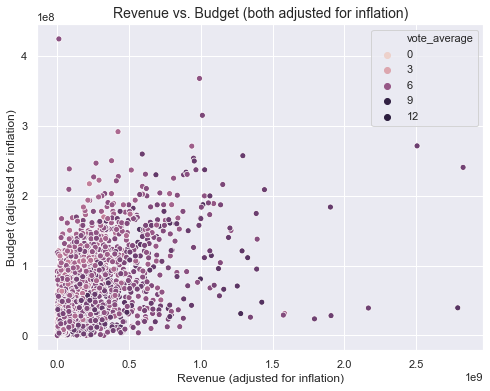

```python
#scatter plot of budget_adj against revenue_adj with vote_average
plt.figure(figsize=(8,6))
sns.scatterplot(x='revenue_adj', y='budget_adj', data=df, hue='vote_average')
plt.title("Revenue vs. Budget (both adjusted for inflation)", fontsize=14)
plt.xlabel("Revenue (adjusted for inflation)")
plt.ylabel("Budget (adjusted for inflation)");
```

As shown from the graph above budget and revenue are positively correlated. Vote average is also included in the graph to illustrate the budget and revenue of the highest scoring movies. Next the revenue against popularity will be investigated.

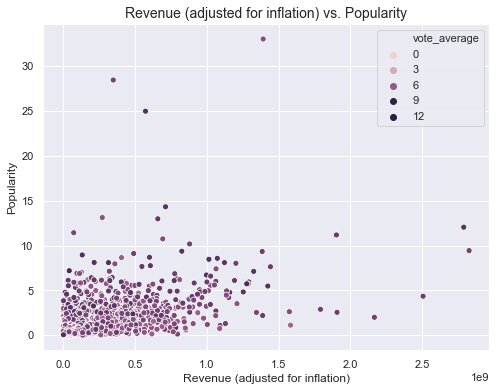

```python
# plotting scatter graph of popularity vs revenue

plt.figure(figsize=(8,6))
sns.scatterplot(x='revenue_adj', y='popularity', data=df, hue='vote_average')
plt.title("Revenue (adjusted for inflation) vs. Popularity", fontsize=14)
plt.xlabel("Revenue (adjusted for inflation)")
plt.ylabel("Popularity");
```

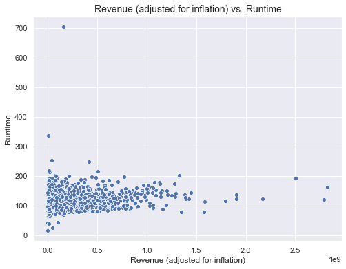

```python
# plotting scatter graph of runtime vs revenue

plt.figure(figsize=(8,6))
sns.scatterplot(x='revenue_adj', y='runtime', data=df)
plt.title("Revenue (adjusted for inflation) vs. Runtime", fontsize=14)
plt.xlabel("Revenue (adjusted for inflation)")
plt.ylabel("Runtime");
```

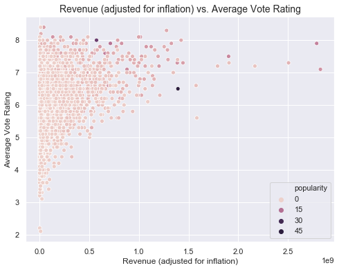

```python
# plotting scatter graph of average voe rating vs revenue

plt.figure(figsize=(8,6))
sns.scatterplot(x='revenue_adj', y='vote_average', data=df, hue='popularity')
plt.title("Revenue (adjusted for inflation) vs. Average Vote Rating", fontsize=14)
plt.xlabel("Revenue (adjusted for inflation)")
plt.ylabel("Average Vote Rating");
```

#### Conclusion

From the above scatter plots it is evident that there evidence of a positive correlation between the budget and revenue (adjusted for inflation). Additionally there is a very weak positive correlation between revenue and popularity score. From the scatterplot, it is clear that there is no significant correlation between runtime and revenue. Finally, the scatterplot between revenue and average vote rating shows that movies that made more revenue have received a high average vote however a significant number of movies with less revenue also received a high average vote rating.

### What kinds of properties are associated with movies that have highest popularity scores?

The next question to answer is what kinds of properties are associated with movies that have highest popularity scores.

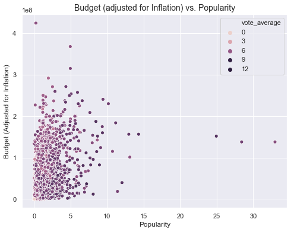

```python
# plotting scatter graph of budget vs popularity and vote_average

plt.figure(figsize=(8,6))
sns.scatterplot(x='popularity', y='budget_adj', data=df, hue='vote_average')
plt.title("Budget (adjusted for Inflation) vs. Popularity", fontsize=14)
plt.xlabel("Popularity")
plt.ylabel("Budget (Adjusted for Inflation)");
```

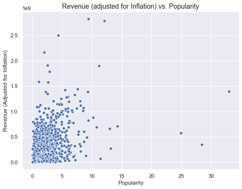

```python
# plotting scatter graph of revenue vs popularity
plt.figure(figsize=(8,6))
sns.scatterplot(x='popularity', y='revenue_adj', data=df)
plt.title("Revenue (adjusted for Inflation) vs. Popularity", fontsize=14)
plt.xlabel("Popularity")
plt.ylabel("Revenue (Adjusted for Inflation)");
```

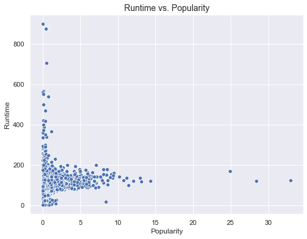

```python
# plotting scatter graph of runtime vs popularity

plt.figure(figsize=(8,6))
sns.scatterplot(x='popularity', y='runtime', data=df)
plt.title("Runtime vs. Popularity", fontsize=14)
plt.xlabel("Popularity")
plt.ylabel("Runtime");
```

#### Conclusions

As shown from the scatterplots above there is a weak correlation between budget and popularity as well as revenue and popularity. From the scatterplot there looks to be little correlation between runtime and popularity, although it can be inferred that films with a runtime under 200 minutes are most popular.

### What kinds of properties are associated with movies that have highest average voting scores?

Next, possible correlations between average vote rating and runtime, budget(adj), revenue(adj), popularity and vote count were considered.

The average rating distribution was first plotted as a histogram and fitted with a kernel density estimate to plot the shape of the distribution.

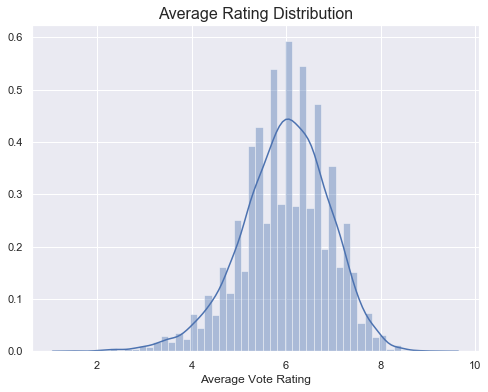

```python
# plotting distribution of average rating

plt.figure(figsize=(8,6))
sns.distplot(df['vote_average'])
plt.title('Average Rating Distribution', fontsize = 16)
plt.xlabel('Average Vote Rating');
```

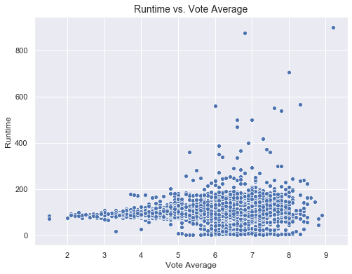

```python
# plotting scatter graph of runtime vs vote average

plt.figure(figsize=(8,6))
sns.scatterplot(x='vote_average', y='runtime', data=df)
plt.title("Runtime vs. Vote Average", fontsize=14)
plt.xlabel("Vote Average")
plt.ylabel("Runtime");
```

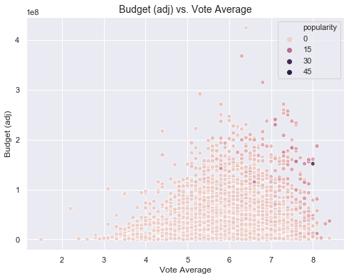

```python
# plotting budget (adj) vs vote average

plt.figure(figsize=(8,6))
sns.scatterplot(x='vote_average', y='budget_adj', data=df, hue='popularity')
plt.title("Budget (adj) vs. Vote Average", fontsize=14)
plt.xlabel("Vote Average")
plt.ylabel("Budget (adj)");
```

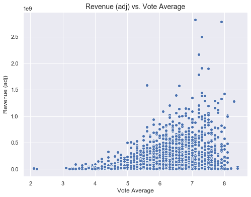

```python
# plotting scatter graph of revenue vs vote average

plt.figure(figsize=(8,6))
sns.scatterplot(x='vote_average', y='revenue_adj', data=df)
plt.title("Revenue (adj) vs. Vote Average", fontsize=14)
plt.xlabel("Vote Average")
plt.ylabel("Revenue (adj)");
```

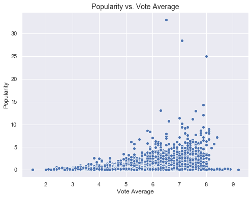

```python
# plotting scatter graph of popularity vs vote average
plt.figure(figsize=(8,6))
sns.scatterplot(x='vote_average', y='popularity', data=df)
plt.title("Popularity vs. Vote Average", fontsize=14)
plt.xlabel("Vote Average")
plt.ylabel("Popularity");
```

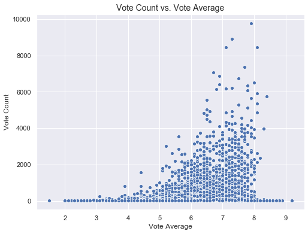

```python
# plotting scatter graph of vote count vs vote average

plt.figure(figsize=(8,6))
sns.scatterplot(x='vote_average', y='vote_count', data=df)
plt.title("Vote Count vs. Vote Average", fontsize=14)
plt.xlabel("Vote Average")
plt.ylabel("Vote Count");
```

#### Conclusions

As illustrated by the scatterplots above the vote average rating is positively correlated with budget, Revenue, popularity and vote count.

### Have movie budgets increased over time?

Next it was of interest to examine movie budgets adjusted over time.

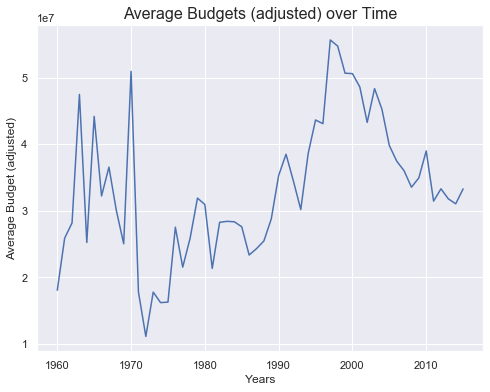

```python
# plotting line graph of average budgets over time

plt.figure(figsize=(8,6))
bud_adj_line = df.groupby('release_year')['budget_adj'].mean()
plt.plot(bud_adj_line)
plt.title('Average Budgets (adjusted) over Time', fontsize=16)
plt.xlabel('Years', fontsize=12)
plt.ylabel('Average Budget (adjusted)', fontsize=12);
```

#### Conclusions

From the above line graph it is evident that average budget (adjusted) was relatively high with significant variance between 1960-1970s and then decreased significantly after 1970s and then started to rise again. From the graph it is evident that average budget peaked in the late 1990s and then has started to decrease again from 2000s-2010s. It is important to note that a significant number of the films in this dataset have null values and therefore this is merely an indication of this dataset and may not hold true for a larger dataset with more budget data.

### Have movie revenues increased over time?

After examining the budgets over time, the next step was to consider the trend in average revenues (adjusted).

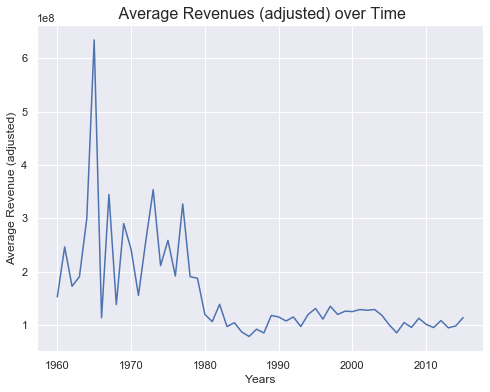

```python
# plotting line graph of  average revenues over time
plt.figure(figsize=(8,6))
revenue_adj_l = df.groupby('release_year')['revenue_adj'].mean()
plt.plot(revenue_adj_l)
plt.title(' Average Revenues (adjusted) over Time', fontsize=16)
plt.xlabel('Years', fontsize=12)
plt.ylabel('Average Revenue (adjusted)', fontsize=12);
```

#### Conclusion

From the above graph it can be seen that average revenue (adjusted for inflation) has fallen overtime, this may be due to the higher number of more recent films in this dataset which may be dragging down the average value for movies after 1980s as from the summary statistics the median release year is 2006. Again it is important to note that there are a significant number of nulls in this dataset and this may not be an accurate reflection of average revenues for movies from 1960-2015. To get a better indication of how revenues and budgets compare over time these will be plotted on the same graph.

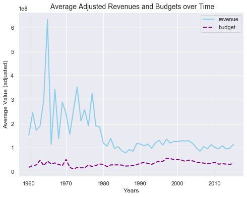

```python
revenue_adj_l = df.groupby('release_year')['revenue_adj'].mean()
bud_adj_line = df.groupby('release_year')['budget_adj'].mean()
plt.figure(figsize=(8,6))
plt.plot(revenue_adj_l, marker='', color='skyblue', linewidth=2, label = 'revenue')
plt.plot(bud_adj_line, marker='', color='purple', linewidth=2, linestyle='dashed', label='budget')
plt.title(' Average Adjusted Revenues and Budgets over Time', fontsize=14)
plt.xlabel('Years', fontsize=12)
plt.ylabel('Average Value (adjusted)', fontsize=12);
plt.legend();
```

If we compare the average movie revenues and budgets (adjusted) on the same graph we can see that although average revenues have fallen over time, the average movie revenue remains higher than the budgets therefore on average profits are still being made.

### Has the popularity score and vote average for movies increased over time?

Popularity over time was considered next.

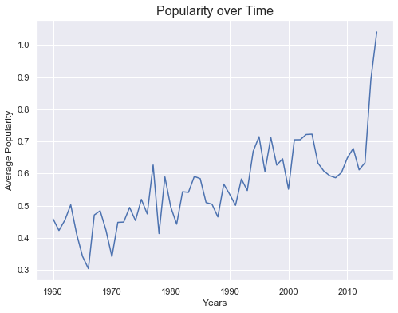

```python
## plotting line graph of popularity rating over time

plt.figure(figsize=(8,6))
pop = df.groupby('release_year')['popularity'].mean()
plt.plot(pop)
plt.title('Popularity over Time', fontsize=16)
plt.xlabel('Years', fontsize=12)
plt.ylabel('Average Popularity', fontsize=12);
```

As shown from the graph above, popularity of recent movies has increased in more recent years which is most likely due to how the popularity score is calculated and these films may be more widely available to stream. The last plot overtime will consider the vote average in relation to release year to understand if the popularity trend is similar to voting average.

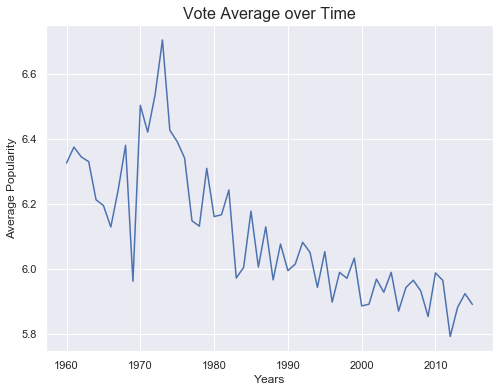

```python
# plotting line graph of vote average rating over time
plt.figure(figsize=(8,6))
vote_avg = df.groupby('release_year')['vote_average'].mean()
plt.plot(vote_avg)
plt.title('Vote Average over Time', fontsize=16)
plt.xlabel('Years', fontsize=12)
plt.ylabel('Average Popularity', fontsize=12);
```

#### Conclusion

As shown from the graphs above although popularity has increased overtime voting averages have actually decreased.

## What are the most widely produced genres from 1960-2015?

Finally, genres of different movies were briefly explored in order to determine the most popular genres from 1960-2015.

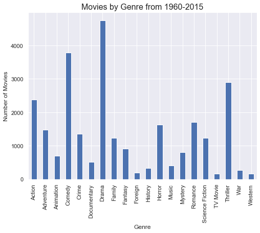

```python
## Plotting bar graph for genres of movies from 1960-2015
plt.figure(figsize=(8,6))
total_genre.plot(kind='bar')
plt.title('Movies by Genre from 1960-2015', fontsize = 16)
plt.xlabel('Genre')
plt.ylabel('Number of Movies');
```

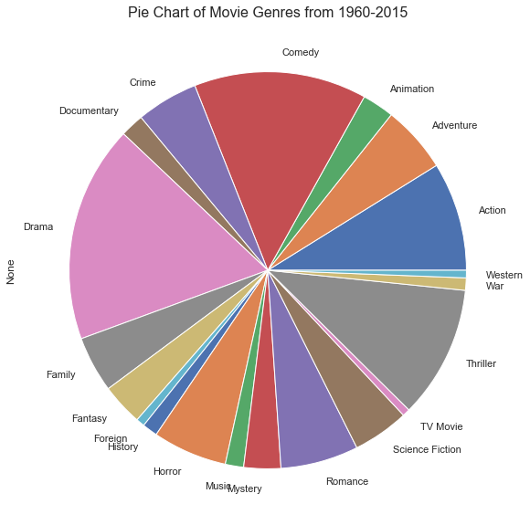

```python
# Plotting pie chart of different genres
total_genre.plot(kind='pie', subplots=True, figsize=(10,10))
plt.title('Pie Chart of Movie Genres from 1960-2015', fontsize = 16);
```

#### Conclusion

From the graphs above it is evident that the most popular genres over the years 1960-2015 are Drama, Comedy, Thriller and Action.

## Conclusions

At the beginning of this analysis the following questions were considered:

1. What kinds of properties are associated with movies that have high revenues?
2. What kinds of properties are associated with movies that have highest popularity scores?
3. What kinds of properties are associated with movies that have highest voting scores?
4. Have movie budgets increased over time?
5. Have movie revenues increased over time?
6. Has the popularity score and average rating for movies increased over time?
7. What are the most popular genres from 1960-2015?

## Citations

https://seaborn.pydata.org/tutorial/distributions.html  
https://seaborn.pydata.org/generated/seaborn.set.html  
https://stackoverflow.com/questions/41286569/get-total-of-pandas-column/41286607  
https://stackoverflow.com/questions/50394099/separate-columns-based-on-genre  
https://stackoverflow.com/questions/58033652/separating-categories-within-one-column-in-my-dataframe  
https://developers.themoviedb.org/3/getting-started/popularity  
https://python-graph-gallery.com/122-multiple-lines-chart/  
https://medium.com/ibm-data-science-experience/markdown-for-jupyter-notebooks-cheatsheet-386c05aeebed